# Ventas de McD

Miguel G.

28/4/2022

Iniciamos nuestro analisis

```r
rm(list=ls())

library(forecast)
library(readxl)
library(tidyverse)
library(tseries)
library(lmtest)

setwd("C:/Users/Miike/Desktop/Pronosticos/sarima")

base <- read_excel("mc_sales.xlsx")

ventas_trim <- ts(base$Sales, start = c(1998,1) , frequency = 4)
```

Grafico la serie para ver su comportamiento

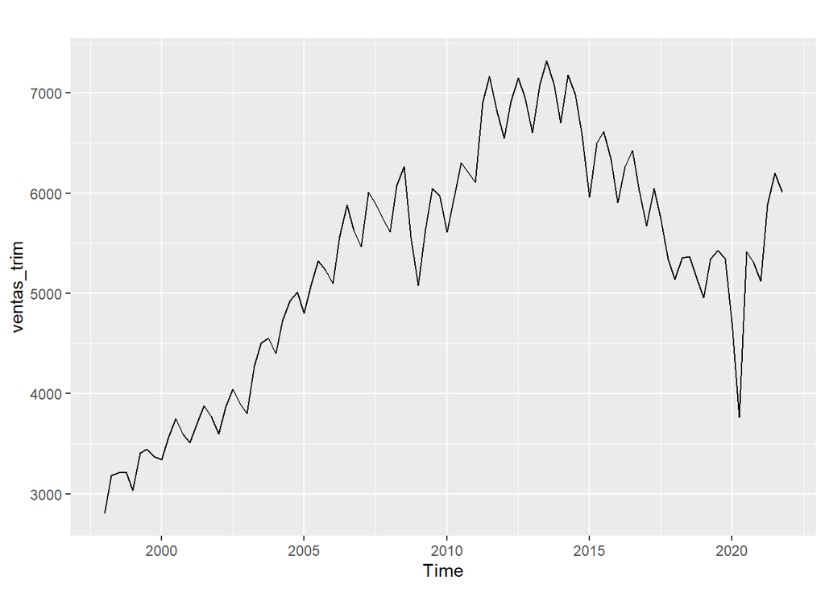

```r
autoplot(ventas_trim)
```

Necesitamos determinar si la serie tiene estacionalidad, la grafica anterior parece indicar que si

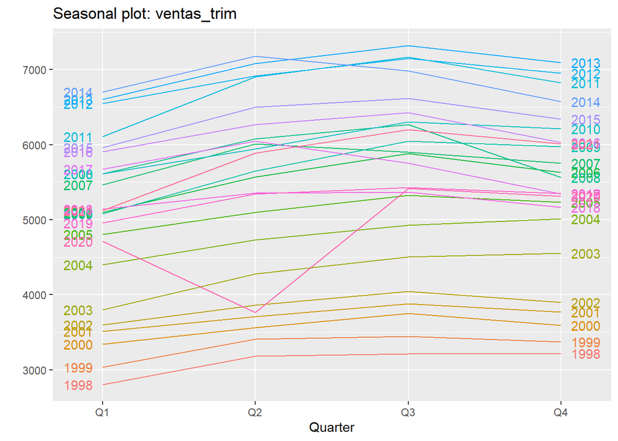

```r
ggseasonplot(ventas_trim, year.labels = TRUE, year.labels.left = TRUE)
```

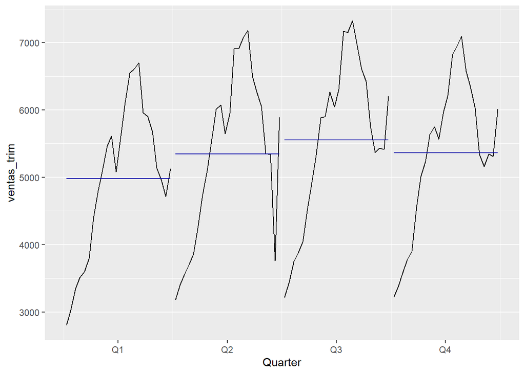

```r
ggsubseriesplot(ventas_trim)
```

La gráfica si presenta estacionalidad, de manera consistente las ventas bajan el primer trimestre del año y durante el tercer trimestre aumentan o suben más las ventas.

Ahora analizamos si se necesita hacer una diferencia estacional o regular para volver la serie estacionaria

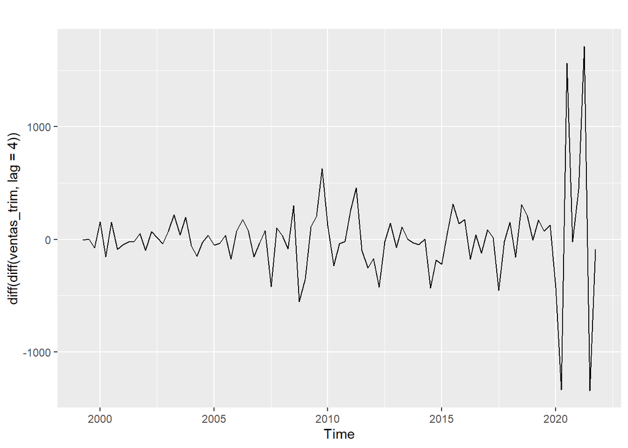

```r
autoplot( diff( diff(ventas_trim, lag = 4)))
```

La serie requiere de diferencias estacionales y de una diferencia estacional para más o menos parecer estacionaria. Podemos utilziar una transformación logaritmica para tratar de minimizar los efectos de la crisis y estabilizar la varianza.

Un logaritmo natural (o neperiano)

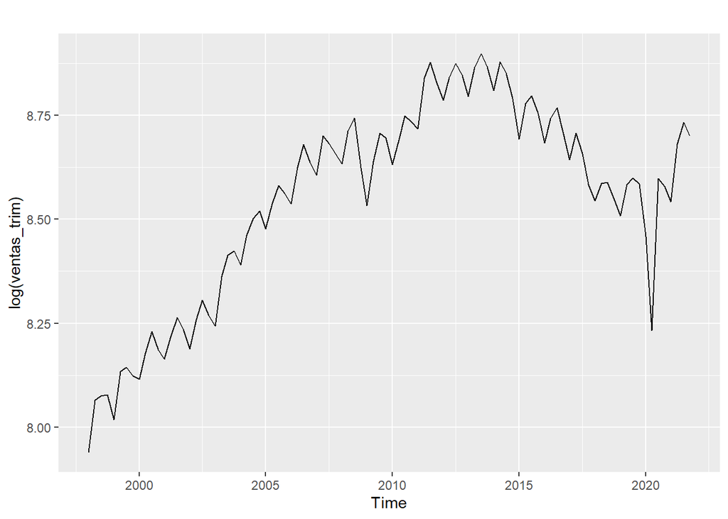

```r
autoplot( log(ventas_trim))
```

Voy a generar una nueva serie que sea el logaritmo natural de las ventas

```r
ln_ventas <- log(ventas_trim)
```

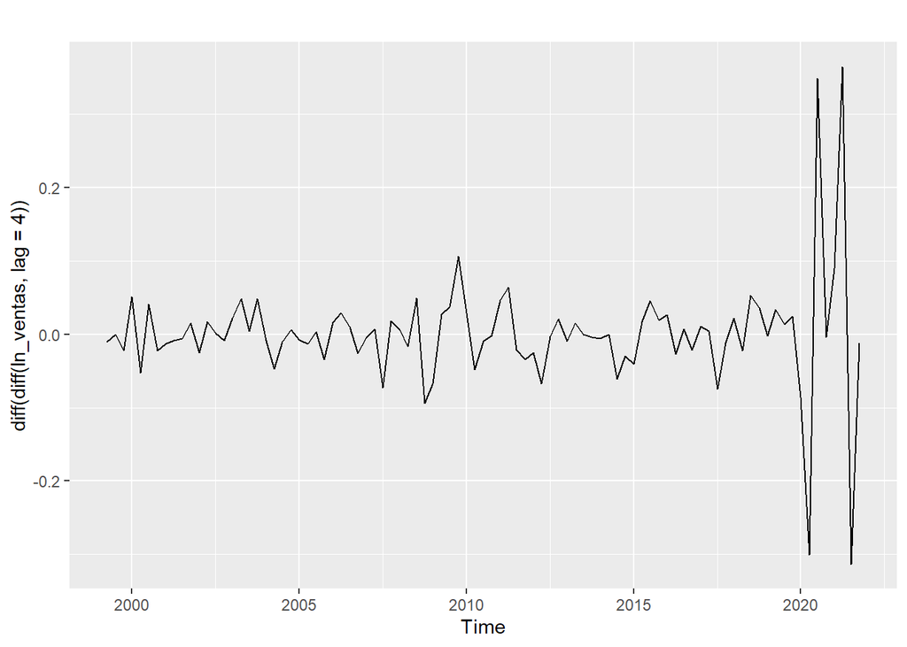

```r
autoplot( diff( diff(ln_ventas, lag = 4)))
```

Parece que la serie requiere de una diferencia estacional y una regular, con la transformación logaritmica, la varianza se estabiliza un poco con excepción de los periodos de crisis.

Analizamos la autocorrelación y autocorrelación parcial para proponer un modelo tentativo

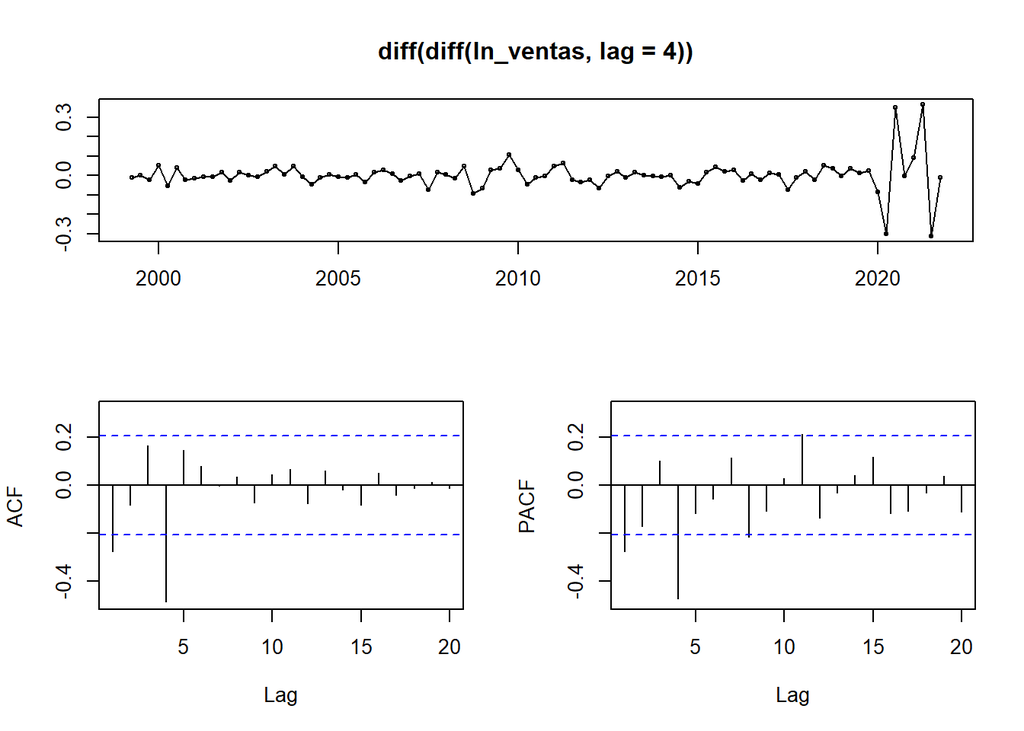

```r
tsdisplay(diff( diff(ln_ventas, lag = 4)))
```

Modelo tentativo que se propone es ARIMA(p,d,q)(P,D,Q)[4]: ARIMA(0,1,1)(0,1,1)[4] Otros serian: ARIMA(1,1,1)(1,1,1)[4] ARIMA(1,1,1)(0,1,1)[4] ARIMA(0,1,1)(1,1,1)[4]

Se estiman los modelos:

```r
modelo_1 <- Arima(ln_ventas, order=c(0,1,1), seasonal = c(0,1,1) )
modelo_2 <- Arima(ln_ventas, order=c(1,1,1), seasonal = c(1,1,1) )
modelo_3 <- Arima(ln_ventas, order=c(1,1,1), seasonal = c(0,1,1) )
modelo_4 <- Arima(ln_ventas, order=c(0,1,1), seasonal = c(1,1,1) )

modelo_5 <- auto.arima(ln_ventas, ic="bic")
```

```r
modelo_1$bic
```

```
## [1] -250.8287
```

```r
modelo_2$bic
```

```
## [1] -242.1211
```

```r
modelo_3$bic
```

```
## [1] -246.3743
```

```r
modelo_4$bic
```

```
## [1] -246.5631
```

```r
modelo_5$bic
```

```
## [1] -253.2352
```

El modelo 5 del autoarima resulto buen modelo y tambien el modelo 1

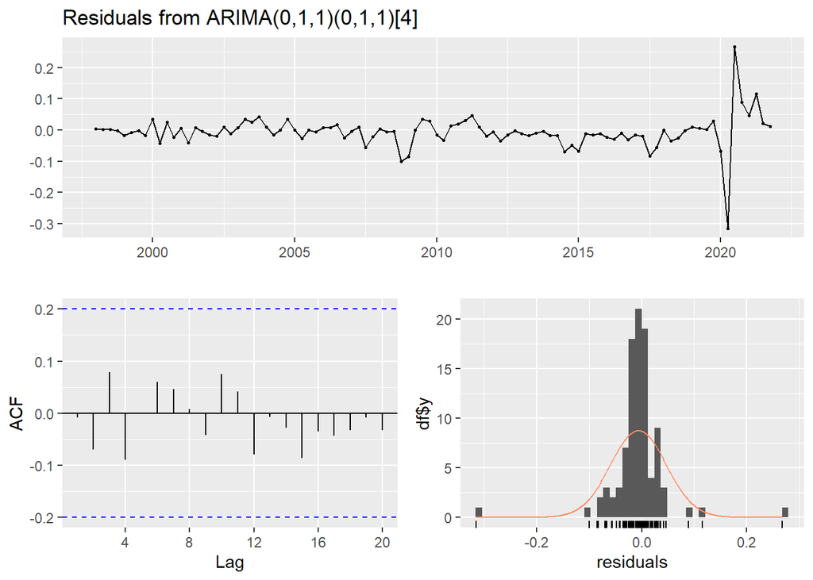

```
##
##  Ljung-Box test
##
## data:  Residuals from ARIMA(0,1,1)(0,1,1)[4]
## Q* = 2.5588, df = 6, p-value = 0.8618
##
## Model df: 2.   Total lags used: 8
```

```r
checkresiduals(modelo_1)
```

```r
coeftest(modelo_1)
```

```
##
## z test of coefficients:
##
##       Estimate Std. Error  z value Pr(>|z|)
## ma1  -0.256841   0.103726  -2.4762  0.01328 *
## sma1 -0.874837   0.079312 -11.0304  < 2e-16 ***
## ---
## Signif. codes:  0 '***' 0.001 '**' 0.01 '*' 0.05 '.' 0.1 ' ' 1
```

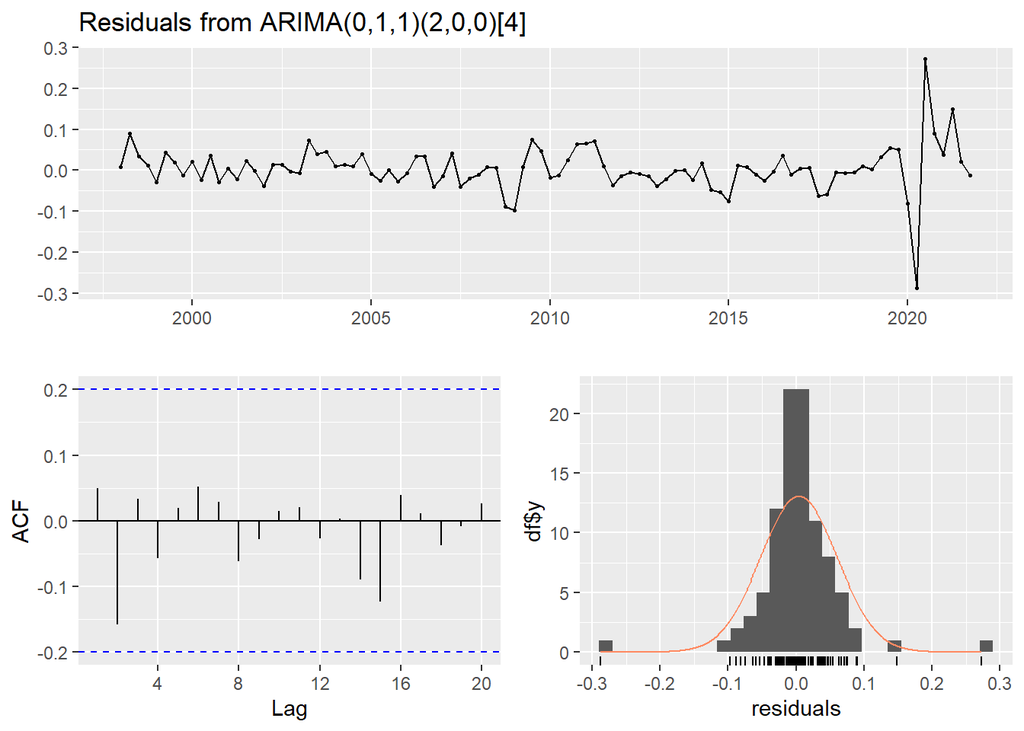

```
##
##  Ljung-Box test
##
## data:  Residuals from ARIMA(0,1,1)(2,0,0)[4]
## Q* = 4.0151, df = 5, p-value = 0.5472
##
## Model df: 3.   Total lags used: 8
```

```r
checkresiduals(modelo_5)
```

```r
coeftest(modelo_5)
```

```
##
## z test of coefficients:
##
##       Estimate Std. Error z value  Pr(>|z|)
## ma1  -0.306769   0.115334 -2.6598  0.007818 **
## sar1  0.180601   0.097878  1.8452  0.065013 .
## sar2  0.568547   0.120608  4.7140 2.429e-06 ***
## ---
## Signif. codes:  0 '***' 0.001 '**' 0.01 '*' 0.05 '.' 0.1 ' ' 1
```

Realizamos el pronostico para los siguientes 8 trimestres

```r
pronostico1 <- forecast(modelo_1, 8)

pronostico2 <- forecast(modelo_5, 8)

pronostico_t1 <- forecast(modelo_2, 8)
pronostico_t2 <- forecast(modelo_3, 8)
pronostico_t3 <- forecast(modelo_4, 8)



pronostico1
```

```
##         Point Forecast    Lo 80    Hi 80    Lo 95    Hi 95
## 2022 Q1       8.640952 8.569854 8.712049 8.532218 8.749686
## 2022 Q2       8.689112 8.600533 8.777691 8.553642 8.824582
## 2022 Q3       8.748110 8.644971 8.851249 8.590372 8.905847
## 2022 Q4       8.711774 8.595890 8.827658 8.534544 8.889003
## 2023 Q1       8.654185 8.522869 8.785502 8.453354 8.855017
## 2023 Q2       8.702346 8.558193 8.846498 8.481884 8.922807
## 2023 Q3       8.761343 8.605409 8.917278 8.522862 8.999825
## 2023 Q4       8.725007 8.558120 8.891895 8.469775 8.980239
```

```r
pronostico2
```

```
##         Point Forecast    Lo 80    Hi 80    Lo 95    Hi 95
## 2022 Q1       8.626547 8.552600 8.700494 8.513455 8.739639
## 2022 Q2       8.523243 8.433265 8.613221 8.385634 8.660852
## 2022 Q3       8.740087 8.636531 8.843643 8.581712 8.898462
## 2022 Q4       8.723350 8.607800 8.838899 8.546632 8.900067
## 2023 Q1       8.689285 8.556896 8.821675 8.486813 8.891758
## 2023 Q2       8.749570 8.604002 8.895137 8.526944 8.972195
## 2023 Q3       8.818216 8.660570 8.975863 8.577116 9.059316
## 2023 Q4       8.797293 8.628429 8.966158 8.539037 9.055549
```

Podemos ver el pronostico graficamente

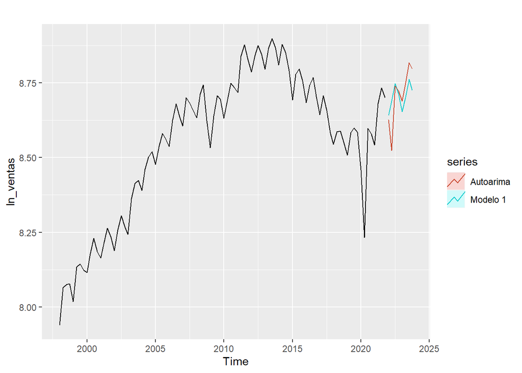

```r
autoplot(ln_ventas)+
  autolayer(pronostico1, series="Modelo 1", PI=FALSE) +
  autolayer(pronostico2, series="Autoarima", PI=FALSE)
```

NOTA: La gráfica y tabla de pronósticos es el pronóstico de la serie de logaritmo natural de las ventas, para revertir la transformación, necesitamos aplicar la función exponencial:

```r
exp(pronostico1$mean)
```

```
##          Qtr1     Qtr2     Qtr3     Qtr4
## 2022 5658.714 5937.908 6298.771 6074.007
## 2023 5734.096 6017.009 6382.679 6154.921
```

```r
exp(pronostico2$mean)
```

```
##          Qtr1     Qtr2     Qtr3     Qtr4
## 2022 5577.785 5030.341 6248.440 6144.727
## 2023 5938.937 6307.972 6756.203 6616.312
```

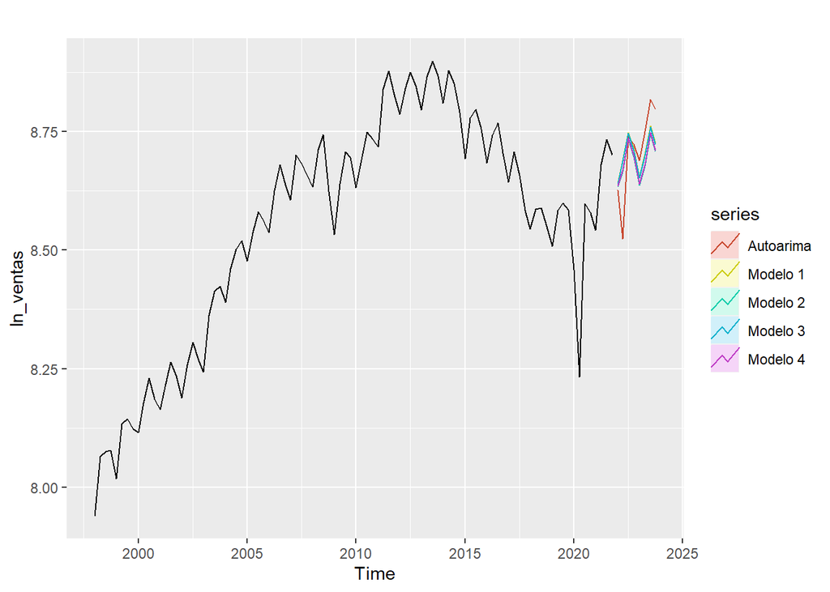

```r
autoplot(ln_ventas)+
  autolayer(pronostico1, series="Modelo 1", PI=FALSE) +
  autolayer(pronostico2, series="Autoarima", PI=FALSE) +
  autolayer(pronostico_t1, series="Modelo 2", PI=FALSE) +
  autolayer(pronostico_t2, series="Modelo 3", PI=FALSE) +
  autolayer(pronostico_t3, series="Modelo 4", PI=FALSE)
```

Suavizacion exponencia estacionales

La suavización exponencial estacional - método de Holt-Winters para hacer un pronostico con este metodo se utiliza la función hw

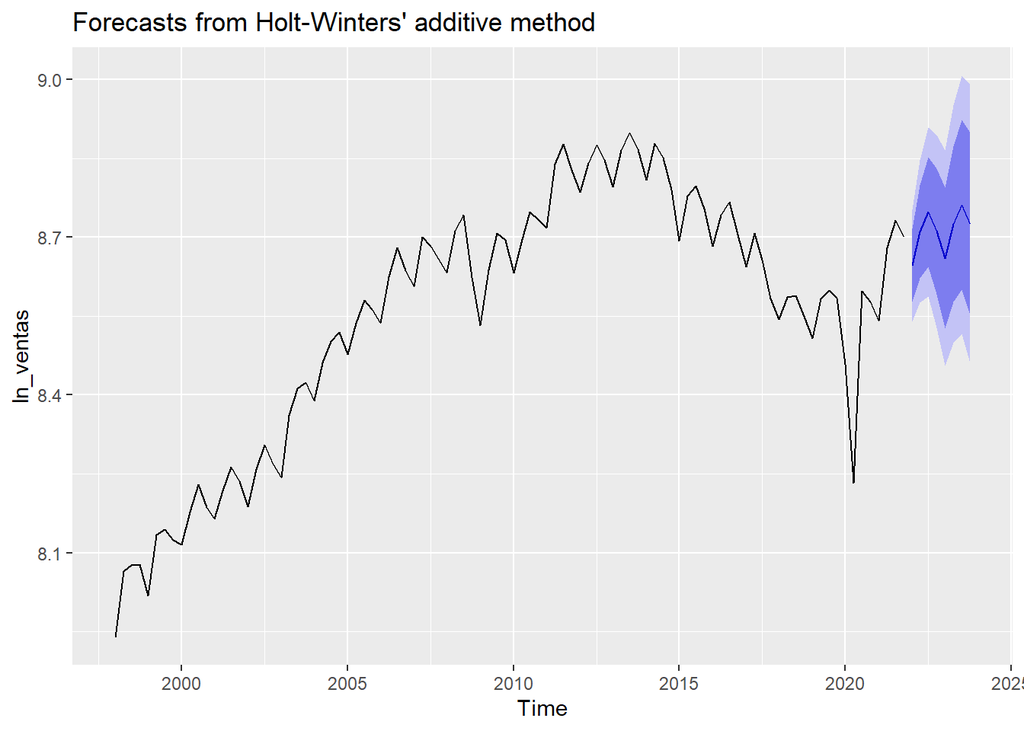

```r
pronositico_suave1 <- forecast((hw(ln_ventas, seasonal = "additive")))

pronositico_suave2 <- forecast((hw(ln_ventas, seasonal = "multiplicative")))


autoplot(pronositico_suave1)
```

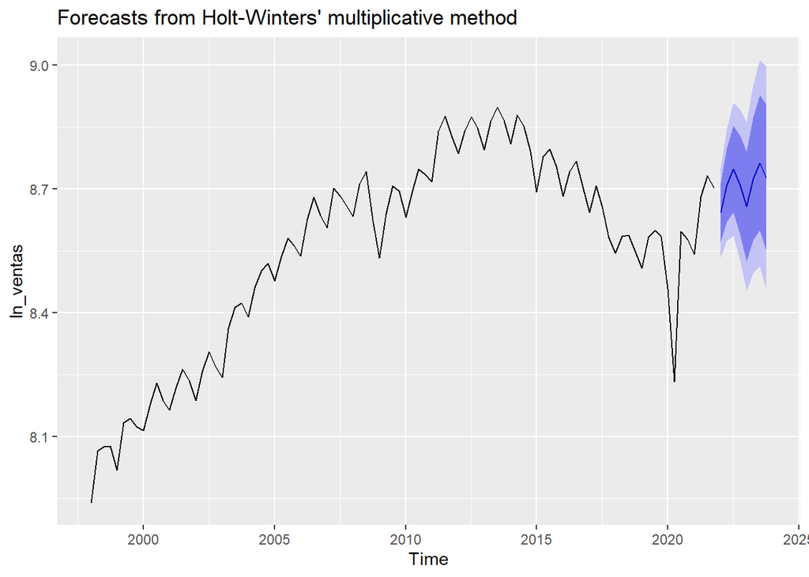

```r
autoplot(pronositico_suave2)
```